# A systems-modelling approach to predict biological responses to extreme heat

- Show All Code
- Hide All Code
- View Source

Published

January 14, 2025

## 1 Introduction

In this supplementary material, we provide extended versions, with code, of our case studies we draw upon within our manuscript. Our case studies focus on plan-insect-microbe interactions, and how these interactions are influenced by extreme heat events. We provide the code for the models we use in our case studies, and the code for the simulations we run to predict the impact of heatwaves on these interactions.

### 1.1 Load packages

```r
# Load required libraries
#install.packages("pacman")
pacman::p_load(devtools, deSolve, ggplot2, dplyr, tidyr, purrr, patchwork)
#devtools::install_github('mrke/NicheMapR')
```

## 2 Case Study 1: Predicting the impact of heatwaves on the growth of plants, microbes and insects

First, we need to get the microclimate, or simulate our own with some heatwaves. This can be done as follows:

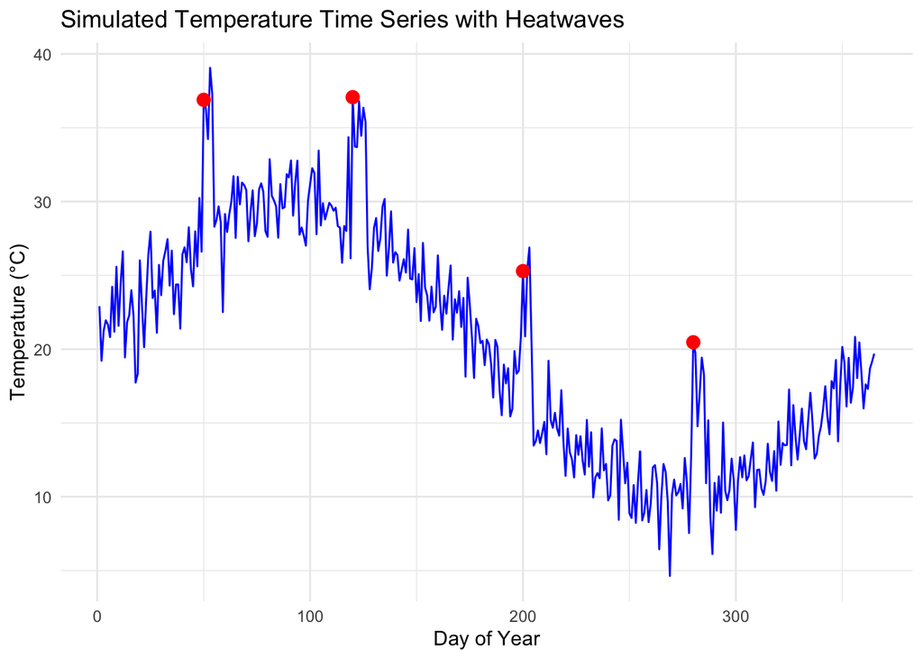

```r
#| label: micro_sim1
#| echo: true
#| eval: false

# Set up environmental model (e.g., microclimate)# 30 days simulation
    #microclim <- microclimate(loc = c(30, -85),   month = 6, n = 30, shade = 0.5)  # 50% shade

# Generate temperature data for DEB models
#temperature <- microclim$output$temp

# Set random seed for reproducibility
set.seed(42)

# Generate a base temperature time series (e.g., daily data for 1 year)
days <- 1:365  # 1 year of daily data
base_temp <- 20 + 10 * sin(2 * pi * days / 365)  # Seasonal temperature

# Add random daily variation
daily_variation <- rnorm(length(days), mean = 0, sd = 2)
temperature_series <- base_temp + daily_variation

# Add a few heatwave events (spikes in temperature)
heatwave_days <- c(50, 120, 200, 280)  # Arbitrary days for heatwaves
heatwave_durations <- c(5, 7, 4, 6)  # Duration of each heatwave
heatwave_intensity <- 8  # Degrees Celsius above the base temperature

for (i in seq_along(heatwave_days)) {
  start <- heatwave_days[i]
  duration <- heatwave_durations[i]
  temperature_series[start:(start + duration - 1)] <- temperature_series[start:(start + duration - 1)] + heatwave_intensity
}

# Create a data frame for the time series
temperature_df <- data.frame(
  Day = days,
  Temperature = temperature_series
)

# Plot the temperature time series
library(ggplot2)
ggplot(temperature_df, aes(x = Day, y = Temperature)) +
  geom_line(color = "blue") +
  geom_point(data = data.frame(Day = heatwave_days,
                               Temperature = temperature_series[heatwave_days]),
             aes(x = Day, y = Temperature), color = "red", size = 3) +
  labs(title = "Simulated Temperature Time Series with Heatwaves",
       x = "Day of Year",
       y = "Temperature (°C)") +
  theme_minimal()
```

Now that we have the temperatures each species is occupying we can include this temperature time series in our DEB models. We can simulate the growth of plants, microbes and insects under these conditions. The outputs of each can be used as input for others. First, we need to create a dynamic energy budget model for each of the three interacting species.

```r
# Define DEB model for insect pest
insect_deb <- function(temp, food) {
  kappa <- 0.8  # Fraction of energy allocated to maintenance and growth
  growth <- kappa * food * exp(-((temp - 25)^2) / 10)  # Simplified growth equation
  reproduction <- (1 - kappa) * food * exp(-((temp - 30)^2) / 15)
  list(growth = growth, reproduction = reproduction)
}

# Define DEB model for plant
plant_deb <- function(temp, light, nutrient) {
  photosynthesis <- light * exp(-((temp - 20)^2) / 10)  # Simplified photosynthesis
  growth <- photosynthesis * nutrient
  respiration <- 0.1 * photosynthesis
  list(growth = growth, respiration = respiration)
}

# Define DEB model for microbe
microbe_deb <- function(temp, organic_matter) {
  growth <- organic_matter * exp(-((temp - 30)^2) / 10)
  respiration <- 0.2 * growth
  list(growth = growth, respiration = respiration)
}
```

Now, we can run the simulation for each species.

```r
# Simulate interactions over 30 days
days <- 1:30
results <- data.frame(day = days,
                      insect_growth = NA,
                      plant_growth = NA,
                      microbe_growth = NA)

# Initialize resources
plant_nutrients <- 1
microbe_organic_matter <- 1
light <- 1  # Assume constant light for simplicity

for (day in days) {
  temp <- temperature[day]

  # Insect feeds on plant
  insect_result <- insect_deb(temp, food = plant_nutrients * 0.1)

  # Plant photosynthesis and growth
  plant_result <- plant_deb(temp, light, nutrient = plant_nutrients)

  # Microbe decompose organic matter
  microbe_result <- microbe_deb(temp, organic_matter = microbe_organic_matter)

  # Update resources
  plant_nutrients <- plant_nutrients + plant_result$growth - insect_result$growth
  microbe_organic_matter <- microbe_organic_matter + insect_result$reproduction - microbe_result$respiration

  # Record results
  results$insect_growth[day] <- insect_result$growth
  results$plant_growth[day] <- plant_result$growth
  results$microbe_growth[day] <- microbe_result$growth
}
```

Now that we have the results, we can plot them to see how the growth of each species changes over time.

```r
# Plot results
library(ggplot2)
ggplot(results, aes(day)) +
  geom_line(aes(y = insect_growth, color = "Insect Growth")) +
  geom_line(aes(y = plant_growth, color = "Plant Growth")) +
  geom_line(aes(y = microbe_growth, color = "Microbe Growth")) +
  labs(y = "Growth Rate", color = "Species") +
  theme_minimal()
```

[output not shown]

## 3 Case Study 2: Developing a DEB model for parasitoid wasps applied to control of an aphid system under heatwaves

#### 3.0.1 Building a DEB model for the parasitoid wasp

To begin, we need to first define the DEB model for the various life-stages. Lets first define the key metabolic processes as functions:

```r
# At any given time we can calculate the key metabolic processes. These then impact the state variables, Reserve, Structure, Maturation (Eh) and Reproduction (Er).

####----------------------------------------------#######
# Larval Stage
####----------------------------------------------#######

  pA_assimilation_larval <- function(f, V, pAm){
    return(pAm * f * V) # Table 5 from Llandres2015
  }

  pC_mobilisation_larval <- function(E, Eg, V, pS, ke, k){
    return(E * ((((Eg * ke) + pS)/(k*E + Eg))) # Table 5 from Llandres2015
  }

  pS_somatic_maintenance_larval  <- function(pM, V, pT){
    return(pM*V) #Table 5 from Llandres2015
  }

  pG_growth_larval  <- function(pC, pM, pT, k2){
    return(k2*pC - pM) #Table 5 from Llandres2015
  }

  pJ_maturity_maintenance_larval  <- function(kj, Ehb){
    return(kj * ehb) #Table 5 from Llandres2015
  }

  pR_reproduction_larval  <- function(k){
    return((1 - k)*pC - pJ) #Table 5 from Llandres2015
  }

####----------------------------------------------#######
# Pupal Stage
####----------------------------------------------#######

 pL_transformation_larvae  <- function(V, kEl){
    return(V*kEl) #Table 5 from Llandres2015
 }
```

```r
# Define parameters for the DEB model
parameter  <- c("kx", "f", "Eg", "v_dot", "pM", "k", "kJ", "kR", "z", "DeltaM", "ha", "sG", "yEV", "sj", "sS", "Exh", "Ebh", "Eeh", "Eeggsh", "kE", "kSA", "kSG", "kSD")

detail <- c("assimilation efficiency","Holling type II scaled functional response","volume-specific cost of structure","energy conductance","volume-specific somatic maintenance","fraction of mobilized reserve allocated to soma","maturity maintenance rate coefficient","fraction of the reproduction buffer fixed into eggs","zoom factor","shape correction coefficient","Weibull ageing acceleration","Gompertz stress coefficient","yield of imago reserve on larval structure","threshold for the onset of pupation","threshold for the onset of silk production","maturity threshold from embryo1 to embryo2","maturity threshold from the embryonic stage to the larval stage maturity threshold at imago" ,"emergence","maturity threshold at egg maturation","reserve and reproduction buffer turnover of the imago","mass coefficient from assimilation to silk production","mass coefficient from growth to silk production","mass coefficient from dissipation to silk production")

values  <- c(0.94, 0.95, 21210, 0.0207, 245.7, 0.930, 0.002, 0.85, 3.98, 0.152, 0.004, 0.0001, 0.8, 0.983, 0.106, 0.0002, 0.044, 5.56, 5.48, 0.291, 0.03, 0.5, 0.94)

flextable::flextable(data.frame(parameter, detail, values))  %>% flextable::set_table_properties(width = .5) %>% flextable::set_table_properties(layout = "autofit") %>% flextable::theme_zebra() %>% flextable::theme_booktabs()
```

Table 1— Parameters for the DEB model

| parameter | detail | values |
| --- | --- | --- |
| kx | assimilation efficiency | 0.9400 |
| f | Holling type II scaled functional response | 0.9500 |
| Eg | volume-specific cost of structure | 21,210.0000 |
| v_dot | energy conductance | 0.0207 |
| pM | volume-specific somatic maintenance | 245.7000 |
| k | fraction of mobilized reserve allocated to soma | 0.9300 |
| kJ | maturity maintenance rate coefficient | 0.0020 |
| kR | fraction of the reproduction buffer fixed into eggs | 0.8500 |
| z | zoom factor | 3.9800 |
| DeltaM | shape correction coefficient | 0.1520 |
| ha | Weibull ageing acceleration | 0.0040 |
| sG | Gompertz stress coefficient | 0.0001 |
| yEV | yield of imago reserve on larval structure | 0.8000 |
| sj | threshold for the onset of pupation | 0.9830 |
| sS | threshold for the onset of silk production | 0.1060 |
| Exh | maturity threshold from embryo1 to embryo2 | 0.0002 |
| Ebh | maturity threshold from the embryonic stage to the larval stage maturity threshold at imago | 0.0440 |
| Eeh | emergence | 5.5600 |
| Eeggsh | maturity threshold at egg maturation | 5.4800 |
| kE | reserve and reproduction buffer turnover of the imago | 0.2910 |
| kSA | mass coefficient from assimilation to silk production | 0.0300 |
| kSG | mass coefficient from growth to silk production | 0.5000 |
| kSD | mass coefficient from dissipation to silk production | 0.9400 |

## References

1.

Llandres, A.L. *et al.* (2015) A dynamic energy budget for the whole life-cycle of holometabolous insects. *Ecol. Monogr.* 85, 353–371